# Импорты

```python
import pandas as pd
import scipy.stats as st
import numpy as np
import matplotlib.pyplot as plt
import seaborn as sns
import statsmodels.api as sm
```

# Обзор датасета

Датасете собрана статистика о баскетбольных матчах по сезонам, с 1999г по 2020г.

Данные

- Season - Сезон YYYY-YYYY
- Player - Имя игрока
- GP - сколько сыграно игр
- MIN - сколько минут играл игрок в этом сезоне
- 3PM - сколько сделано трехочковых
- height - Рост игрока

```python
df = pd.read_csv("/content/players.csv")[["Season", "Player", "GP", "MIN", "3PM", "height_cm"]]
df.head()
```

|  | Season | Player | GP | MIN | 3PM | height_cm |
| --- | --- | --- | --- | --- | --- | --- |
| 0 | 1999 - 2000 | Shaquille O'Neal | 79 | 3163.0 | 0 | 216.0 |
| 1 | 1999 - 2000 | Vince Carter | 82 | 3126.0 | 95 | 198.0 |
| 2 | 1999 - 2000 | Karl Malone | 82 | 2947.0 | 2 | 206.0 |
| 3 | 1999 - 2000 | Allen Iverson | 70 | 2853.0 | 89 | 183.0 |
| 4 | 1999 - 2000 | Gary Payton | 82 | 3425.0 | 177 | 193.0 |

Избавимся от пропусков, просто удалив их

```python
df.shape
```

```
(53949, 6)
```

```python
df.dropna(inplace=True)
df.shape
```

```
(53875, 6)
```

Итого, мы имеем четрые метрики:

- GP - сколько сыграно игр
- MIN - сколько минут играл игрок в этом сезоне
- 3PM - сколько сделано трехочковых
- height - Рост игрока

Разобьем наш датасет на сегменты по периодам:

- 1999 - 2006
- 2007 - 2013
- 2014 - 2019

```python
df["Season"] = df["Season"].str.slice(stop=4).astype(int)
```

```python
before2006 = (
    df
    .loc[df['Season'] <= 2006]
    .groupby('Player')["GP", "MIN", "3PM", "height_cm"]
    .agg({'GP': 'sum', 'MIN': 'sum', "3PM": 'sum', "height_cm": 'mean'})
)

before2013 = (
    df
    .loc[(df['Season'] > 2006) & (df['Season'] <= 2013)]
    .groupby('Player')["GP", "MIN", "3PM", "height_cm"]
    .agg({'GP': 'sum', 'MIN': 'sum', "3PM": 'sum', "height_cm": 'mean'})
)

before2020 = (
    df
    .loc[df['Season'] > 2013]
    .groupby('Player')["GP", "MIN", "3PM", "height_cm"]
    .agg({'GP': 'sum', 'MIN': 'sum', "3PM": 'sum', "height_cm": 'mean'})
)
```

# Задания 2 - 3

Сгенерируем всевозможные пары сегментов

```python
segments = {
            "before2006": before2006,
            "before2013": before2013,
            "before2020": before2020
            }
pairs = [(a, b) for idx, a in enumerate(list(segments.keys())) for b in list(segments.keys())[idx + 1:]]
```

Здесь и далее уровень значимости проверяемых гипотез - `0.05`

## Критерий Cтьюдента

Проверим гипотезу о равенстве средних

```python
for pair in pairs:
    for metric in ["GP", "MIN", "3PM", "height_cm"]:
        pv = st.ttest_ind(segments[pair[0]][metric],
                             segments[pair[1]][metric]).pvalue
        print(*pair, f'metric: {metric}', f"pvalue: {pv}")
```

```
before2006 before2013 metric: GP pvalue: 4.832684176056954e-30
before2006 before2013 metric: MIN pvalue: 5.657644586296069e-31
before2006 before2013 metric: 3PM pvalue: 0.00012197603878708421
before2006 before2013 metric: height_cm pvalue: 3.842392589728754e-17
before2006 before2020 metric: GP pvalue: 7.30273631996411e-48
before2006 before2020 metric: MIN pvalue: 5.109901132255788e-61
before2006 before2020 metric: 3PM pvalue: 0.24427445651493318
before2006 before2020 metric: height_cm pvalue: 4.798190462235338e-34
before2013 before2020 metric: GP pvalue: 0.03386476473740247
before2013 before2020 metric: MIN pvalue: 2.6429489660639253e-05
before2013 before2020 metric: 3PM pvalue: 7.688069892105326e-06
before2013 before2020 metric: height_cm pvalue: 6.273394289346706e-07
```

Как видим, почти везде значение `pvalue` получилось довольно небольшим. То есть, почти для всех сезонов и метрик мы отвергаем гипотезу о равенестве средних. Однако, мы не отвергаем гипотезу о равенстве средних для количества заброшенных трехочковых между сезонами 1999-2006 гг. и 2014 - 2020 гг.

Для того, чтобы узнать в какую сторону изменились среднии применим двухвыборочный критерий Стьюдента

```python
for pair in pairs:
    for metric in ["GP", "MIN", "3PM", "height_cm"]:
        if pair == ("before2006",  "before2020") and metric == "3PM":
            continue
        pv = st.ttest_ind(segments[pair[0]][metric],
                             segments[pair[1]][metric],
                          alternative="less").pvalue
        print(*pair, f'metric: {metric}', f"pvalue: {pv}")
```

```
before2006 before2013 metric: GP pvalue: 1.0
before2006 before2013 metric: MIN pvalue: 1.0
before2006 before2013 metric: 3PM pvalue: 0.9999390119806064
before2006 before2013 metric: height_cm pvalue: 1.0
before2006 before2020 metric: GP pvalue: 1.0
before2006 before2020 metric: MIN pvalue: 1.0
before2006 before2020 metric: height_cm pvalue: 1.0
before2013 before2020 metric: GP pvalue: 0.9830676176312988
before2013 before2020 metric: MIN pvalue: 0.9999867852551697
before2013 before2020 metric: 3PM pvalue: 3.844034946052663e-06
before2013 before2020 metric: height_cm pvalue: 0.9999996863302855
```

Во всех случаях мы можем утверждать, что среднее значение метрик уменьшилось. Кроме среднего количества забитых трехочковых между сезонами 2007-2013 гг. и 2014 - 2020 гг. там оно увиличилось.

## Критерий Фишера

```python
for pair in pairs:
    for metric in ["GP", "MIN", "3PM", "height_cm"]:
        pv = st.f_oneway(segments[pair[0]][metric],
                             segments[pair[1]][metric]).pvalue
        print(*pair, f'metric: {metric}', f"pvalue: {pv}")
```

```
before2006 before2013 metric: GP pvalue: 4.832684176036624e-30
before2006 before2013 metric: MIN pvalue: 5.657644586271315e-31
before2006 before2013 metric: 3PM pvalue: 0.00012197603878653849
before2006 before2013 metric: height_cm pvalue: 3.842392589708456e-17
before2006 before2020 metric: GP pvalue: 7.302736319924074e-48
before2006 before2020 metric: MIN pvalue: 5.109901132228183e-61
before2006 before2020 metric: 3PM pvalue: 0.24427445651360535
before2006 before2020 metric: height_cm pvalue: 4.798190462198374e-34
before2013 before2020 metric: GP pvalue: 0.033864764736939335
before2013 before2020 metric: MIN pvalue: 2.6429489660282276e-05
before2013 before2020 metric: 3PM pvalue: 7.688069892006897e-06
before2013 before2020 metric: height_cm pvalue: 6.273394289257047e-07
```

Для критерия Фишера мы получили те же результаты, что и с критерием Стьюдента

Воспользуемся критерием Фишера для трех сегментов

```python
for metric in ["GP", "MIN", "3PM", "height_cm"]:
        pv = st.f_oneway(before2006[metric],
                         before2013[metric],
                         before2020[metric]
                         ).pvalue
        print(f'metric: {metric}', f"pvalue: {pv}")
```

```
metric: GP pvalue: 1.2459831045152871e-48
metric: MIN pvalue: 1.3295118577871204e-61
metric: 3PM pvalue: 5.552850008476353e-06
metric: height_cm pvalue: 8.31826222218004e-34
```

Для всех четырех метрик гипотезу о равенстве средних отвергаем

## Критерий Манна-Уитни

Проверим схожеть распределений метрик по всему датасету и по каждому сегменту.

Проверим схожесть распределений метрик по датасету

```python
metrics = ["GP", "MIN", "3PM", "height_cm"]
pairs_metrics = [(a, b) for idx, a in enumerate(metrics) for b in metrics[idx + 1:]]

for pair in pairs_metrics:
        pv = st.mannwhitneyu(
            df[pair[0]].values,
            df[pair[1]].values).pvalue
        print(*pair, "\t", f"pvalue: {pv}")
```

```
GP MIN 	 pvalue: 0.0
GP 3PM 	 pvalue: 0.0
GP height_cm 	 pvalue: 0.0
MIN 3PM 	 pvalue: 0.0
MIN height_cm 	 pvalue: 0.0
3PM height_cm 	 pvalue: 0.0
```

Как несложно заметить распределения метрик по датасету сильно разняться. Гипотезу о равенстве распределений отвергаем

Проверим схожесть метрик распределений по сегментам

```python
for pair in pairs:
    for metric in ["GP", "MIN", "3PM", "height_cm"]:
        pv = st.mannwhitneyu(
                             segments[pair[0]][metric].values,
                             segments[pair[1]][metric].values,
                          ).pvalue
        print(*pair, f'metric: {metric}', f"pvalue: {pv}")
```

```
before2006 before2013 metric: GP pvalue: 0.0016970080122557505
before2006 before2013 metric: MIN pvalue: 0.022003041899697744
before2006 before2013 metric: 3PM pvalue: 8.334462491948964e-05
before2006 before2013 metric: height_cm pvalue: 4.922695800751405e-18
before2006 before2020 metric: GP pvalue: 3.256776652038576e-08
before2006 before2020 metric: MIN pvalue: 4.882038659982026e-13
before2006 before2020 metric: 3PM pvalue: 2.0474616440189764e-07
before2006 before2020 metric: height_cm pvalue: 2.7298123857082564e-34
before2013 before2020 metric: GP pvalue: 1.1705403842393648e-09
before2013 before2020 metric: MIN pvalue: 6.148113424816397e-17
before2013 before2020 metric: 3PM pvalue: 0.05176335578781351
before2013 before2020 metric: height_cm pvalue: 1.1974662524716755e-06
```

Как ни странно, это связано с сильно отличающимся размером сегментов.

Можем заметить, что гипотезу о равенстве распределений не можем отвергнуть только для распределения кол-ва трехочковых бросков в сезонах между 2007-2013 гг. и 2014 - 2020 гг.

# Задание 4

## Точные доверительные интервалы

```python
def accurate_confidence_interval(sample, alpha=0.05) -> list[float]:
    """
    Строит 1 - alpha точный доверительный интервал
    """
    n_obs = len(sample)
    mean = sample.mean()
    std = sample.std()
    t_rv = st.t(n_obs - 1)
    t_crit = t_rv.ppf(1 - alpha / 2)

    left = mean - t_crit*(std / (n_obs**0.5))
    right = mean + t_crit*(std / (n_obs**0.5))

    return [left, right]
```

```python
for seg in ["before2006", "before2013", "before2020"]:
    for metric in ["GP", "MIN", "3PM", "height_cm"]:
        print(seg, metric, accurate_confidence_interval(segments[seg][metric].values))
    print("---")
```

```
before2006 GP [105.75195764492796, 117.03213326416295]
before2006 MIN [2766.646874805964, 3118.3788827697927]
before2006 3PM [78.76508202214372, 91.77090282634113]
before2006 height_cm [198.61337145280973, 199.3759864115481]
---
before2013 GP [80.77644086133783, 84.97790729935171]
before2013 MIN [2026.4199264335614, 2145.165082031884]
before2013 3PM [70.79576763165818, 76.18468488488793]
before2013 height_cm [196.9294864373777, 197.353427355002]
---
before2020 GP [78.65204586773216, 81.64146885459361]
before2020 MIN [1898.2546421086367, 1977.8110306457424]
before2020 3PM [79.45602043855305, 84.04453863710853]
before2020 height_cm [196.29565492475902, 196.62433874682804]
---
```

Доверительные интервалы действительно соответствуют результатам критерия Стьюдента

## Эфроновы доверительные интервалы

```python
def bootstrap_confidence_interval(sample, stat, alpha=0.05):
    """
    Стоит эфронов 1 - alpha доверительный интервал для выбранной статистики stat
    """
    n = sample.shape[0]
    distribution_lst = []
    for _ in range(100):
        a_ = np.random.choice(sample, size=n, replace=True)
        distribution_lst.append(stat(a_))

    return np.percentile(distribution_lst, q=[alpha / 2 * 100, (1 - alpha / 2) * 100])
```

```python
for seg in ["before2006", "before2013", "before2020"]:
    for metric in ["GP", "MIN", "3PM", "height_cm"]:
        print(seg, metric, bootstrap_confidence_interval(segments[seg][metric].values, np.mean))
    print("---")
```

```
before2006 GP [106.33307292 118.11455966]
before2006 MIN [2764.83488636 3129.23159683]
before2006 3PM [79.50129025 94.54933712]
before2006 height_cm [198.65149986 199.36942366]
---
before2013 GP [81.34620979 84.81459135]
before2013 MIN [2037.83497884 2138.86143951]
before2013 3PM [70.44385486 76.51606126]
before2013 height_cm [196.89482812 197.35021274]
---
before2020 GP [78.67578271 81.50350354]
before2020 MIN [1899.86616917 1981.35306583]
before2020 3PM [79.83116381 83.64511508]
before2020 height_cm [196.30266296 196.63954343]
---
```

Эфроновы доверительные интервалы тоже не разняться с результатами критерия Стьюдента

# Задание 5

## Проверка выборки на нормальность

Проверим довольно очевидную гипотезу: рост игроков нормально распеределен.

Воспользуемся критерием Шапиро-Уилка

```python
for seg in ["before2006", "before2013", "before2020"]:
        print(seg, st.shapiro(segments[seg]["height_cm"].values).pvalue)
```

```
before2006 2.726834108854456e-16
before2013 2.539937660598521e-24
before2020 9.242043155091519e-31
```

```python
st.shapiro(df["height_cm"].values).pvalue
```

```
0.0
```

Изобразим на графике распределение роста в датасете.

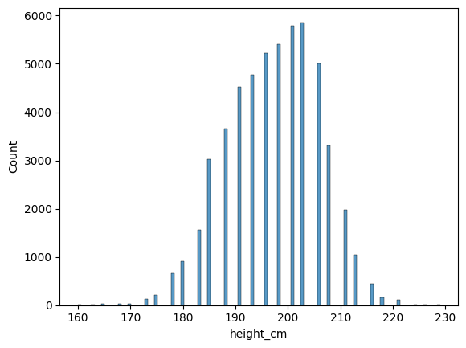

```python
sns.histplot(df["height_cm"])
```

Несмотря на то, что графически распределение напоминает нормальное, оно таковым не является.

Проверим на нормальность остальные метрики

```python
for seg in ["before2006", "before2013", "before2020"]:
    for metric in ["GP", "MIN", "3PM"]:
        print(seg, metric, st.shapiro(segments[seg][metric].values).pvalue)
    print("---")
```

```
before2006 GP 0.0
before2006 MIN 0.0
before2006 3PM 0.0
---
before2013 GP 0.0
before2013 MIN 0.0
before2013 3PM 0.0
---
before2020 GP 0.0
before2020 MIN 0.0
before2020 3PM 0.0
---
```

Как оказалось, распределение каждой метрики далеко от нормального.

Результаты полученные тестом Стьюдента и Фишера больше не являются достоверными.

## Проверка равенства дисперсий

```python
def f_test(group1, group2):
    variance1 = np.var(group1, ddof=1)
    variance2 = np.var(group2, ddof=1)

    f_value = variance1 / variance2

    df1 = len(group1) - 1
    df2 = len(group2) - 1

    p_value = st.f.cdf(f_value, df1, df2)

    return {"f_statistic:": f_value, "p_value": p_value}
```

```python
for pair in pairs:
    for metric in ["GP", "MIN", "3PM", "height_cm"]:
        pv = f_test(
                             segments[pair[0]][metric].values,
                             segments[pair[1]][metric].values,
                          )
        print(*pair, f'metric: {metric}', f"res: {pv}")
    print("---")
```

```
before2006 before2013 metric: GP res: {'f_statistic:': 2.342143516937692, 'p_value': 0.9999999999999999}
before2006 before2013 metric: MIN res: {'f_statistic:': 2.8508578255108814, 'p_value': 0.9999999999999999}
before2006 before2013 metric: 3PM res: {'f_statistic:': 1.8925879914719594, 'p_value': 0.9999999999999999}
before2006 before2013 metric: height_cm res: {'f_statistic:': 1.0514377046778218, 'p_value': 0.923299166412132}
---
before2006 before2020 metric: GP res: {'f_statistic:': 2.800497995721003, 'p_value': 0.9999999999999999}
before2006 before2020 metric: MIN res: {'f_statistic:': 3.8446069410472776, 'p_value': 0.9999999999999999}
before2006 before2020 metric: 3PM res: {'f_statistic:': 1.5801885044998065, 'p_value': 0.9999999999999999}
before2006 before2020 metric: height_cm res: {'f_statistic:': 1.058844696515105, 'p_value': 0.9569570971443374}
---
before2013 before2020 metric: GP res: {'f_statistic:': 1.195698715927793, 'p_value': 0.9999999999999997}
before2013 before2020 metric: MIN res: {'f_statistic:': 1.3485789809101805, 'p_value': 0.9999999999999999}
before2013 before2020 metric: 3PM res: {'f_statistic:': 0.8349352905229075, 'p_value': 4.211535941380634e-16}
before2013 before2020 metric: height_cm res: {'f_statistic:': 1.0070446321302056, 'p_value': 0.6246294755018189}
---
```